# HW12_B66050

Pavel Shumejko

May, 11 2017

## Exercise 1

With Excel we can create a pivot tabel that contains the necessary information. Using the pivot table we can conclude that the most important sale reasons in France are:

1. Price
2. on Promotion
3. Other
4. Review
5. Manufacturer

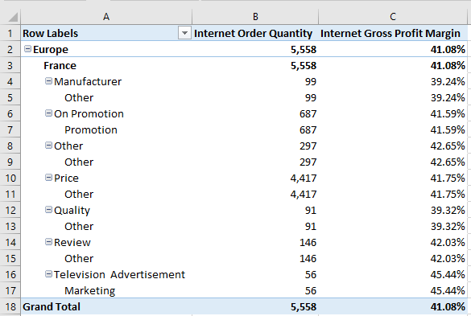

## Exercise 2

Using Excel we can calculate the revenue increase as the difference between the sales amount from different years.

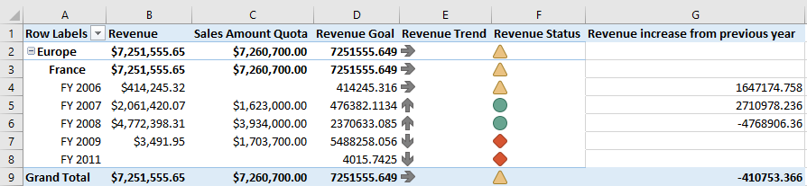

## Exercise 3

Using Excel we can filter the fiscal year to only show 2009 and we can see that **Cluster 3** brought the largest internet gross profit in fiscal year 2009.

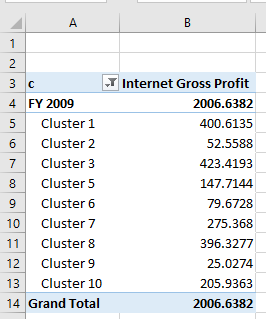

## Exercise 4

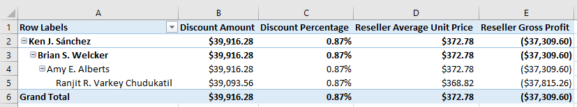

## Exercise 5

Perspectives are a simpler way of representing a certain aspect of the cube. The Direct Sales perspective might be of interest of the employees that work directly in sales as it contains information about the destination currency and territory, costumer info (example contact information) the destined product and other dimensions that are useful for them in order to interact with the costumers and do their job better (plan currency transformation, contact costumers, trace the internet sales and have knowledge of delivery and ship dates) The Channel Sales perspective has similar to the Direct Sales but instead of costumer info it contains employer (sale and resale) info. This can be an interest of both HR to manage the work flow and its benefits from the employees and the employees themselves to track their productivity. The Sales Summary perspective provides information about the total sales, products, promotions etc. This can be useful for Finance to do finance calculations. Also and more important it can be used by the departments that do the planning and development of the products as with this perspective they have overview of the sales summary. The Finance perspective might be of interest of the Finance department as they do the finance calculations and anything else connected with Fiscal reporting and the end of year or average exchange rates. The Sales Targets perspective might be of interest of the Executives, HR and anyone else who is interested in monitoring the quality of the work of the employees and their productivity as this perspective has information about the employees as well as the product they sell, the territory and the date (example Fiscal year).